# **Used Cars Price Prediction**

## **Problem Definition**

### **The Context:**

This problem revolves around the used cars market. Understanding the factors that influence the price of used cars. Analizing these factors can provide insights into market trends, costumer preferences and pricing strategies

- Why is this problem important to solve?

Is a problem important to solve because it benefits the costumer as much as the seller. The costumer can understand the factors that affect used car price to be inform when he wants to buy and make better decisions and deals. It also benefits the seller because they can use this information to set competitive prices, optimize the inventory and improve sales efficiency

### **The objective:**

- What is the intended goal?

The primary goal is to develop a predictive model that accurately estimates the price of a used car based on its attributes. By doing so, stakeholders can gain insights into the pricing dynamics of the used car market and make data-driven decisions.

### **The key questions:**

- What are the key questions that need to be answered?
1. What are the most influential factors determining the price of a used car?
2. How do different attributes such as brand, model, year, mileage, fuel type, etc., correlate with the price of a used car?
3. How do categorical variables like fuel type, transmission, and owner type impact the price prediction?
4. What is the significance of missing values in certain features, and how should they be handled during analysis?

### **The problem formulation**:

- What is it that we are trying to solve using data science?

Using data science techniques, we aim to build a regression model that predicts the price of used cars based on various features such as brand, model, year of manufacture, mileage, fuel type, transmission type, etc. The model will be trained on historical data with known prices, and its performance will be evaluated using appropriate metrics to ensure its reliability and accuracy in predicting prices for new instances. Ultimately, the goal is to provide stakeholders with a valuable tool for estimating the value of used cars in the market.

### **Data Dictionary**

**S.No.** : Serial Number

**Name** : Name of the car which includes Brand name and Model name

**Location** : The location in which the car is being sold or is available for purchase (Cities)

**Year** : Manufacturing year of the car

**Kilometers_driven** : The total kilometers driven in the car by the previous owner(s) in KM

**Fuel_Type** : The type of fuel used by the car (Petrol, Diesel, Electric, CNG, LPG)

**Transmission** : The type of transmission used by the car (Automatic / Manual)

**Owner** : Type of ownership

**Mileage** : The standard mileage offered by the car company in kmpl or km/kg

**Engine** : The displacement volume of the engine in CC

**Power** : The maximum power of the engine in bhp

**Seats** : The number of seats in the car

**New_Price** : The price of a new car of the same model in INR 100,000

**Price** : The price of the used car in INR 100,000 (**Target Variable**)

### **Loading libraries**

```python
# Importing libraries for data manipulation
import numpy as np

import pandas as pd

# Importing libraries for data visualization
import seaborn as sns

import matplotlib.pyplot as plt

# Importing libraries for building linear regression model
import statsmodels.api as sm

from statsmodels.stats.outliers_influence import variance_inflation_factor

# Importing libraries for scaling the data
from sklearn.preprocessing import MinMaxScaler

# To ignore warnings
import warnings
warnings.filterwarnings("ignore")

from scipy.stats import skew

import seaborn as sns
sns.set()

from sklearn.model_selection import train_test_split
from scipy.stats import skew

import missingno as msno # to get visualization on missing values

# To build models for prediction
from sklearn.model_selection import train_test_split, cross_val_score, KFold
from sklearn.linear_model import LinearRegression, Ridge, Lasso, ElasticNet
from sklearn.tree import DecisionTreeRegressor
from sklearn.ensemble import RandomForestRegressor,BaggingRegressor

# For tuning the model
from sklearn.model_selection import GridSearchCV
```

### **Let us load the data**

```python
from google.colab import drive
drive.mount('/content/drive')


df = pd.read_csv('/content/drive/MyDrive/Capstone Project/used_cars.csv')
```

## Data Overview

- Observations
- Sanity checks

```python
df.info()
```

```
<class 'pandas.core.frame.DataFrame'>
RangeIndex: 7253 entries, 0 to 7252
Data columns (total 14 columns):
 #   Column             Non-Null Count  Dtype
---  ------             --------------  -----
 0   S.No.              7253 non-null   int64
 1   Name               7253 non-null   object
 2   Location           7253 non-null   object
 3   Year               7253 non-null   int64
 4   Kilometers_Driven  7253 non-null   int64
 5   Fuel_Type          7253 non-null   object
 6   Transmission       7253 non-null   object
 7   Owner_Type         7253 non-null   object
 8   Mileage            7251 non-null   float64
 9   Engine             7207 non-null   float64
 10  Power              7078 non-null   float64
 11  Seats              7200 non-null   float64
 12  New_price          1006 non-null   float64
 13  Price              6019 non-null   float64
dtypes: float64(6), int64(3), object(5)
memory usage: 793.4+ KB
```

```python
# We drop the duplicates
df.drop_duplicates(inplace=True)
```

```python
#We drop S.No because it will not be useful for the model since it's only a serial number
df.drop(columns=['S.No.'], inplace=True)
```

```python
df.isnull().sum()
```

```
Name                    0
Location                0
Year                    0
Kilometers_Driven       0
Fuel_Type               0
Transmission            0
Owner_Type              0
Mileage                 2
Engine                 46
Power                 175
Seats                  53
New_price            6247
Price                1234
dtype: int64
```

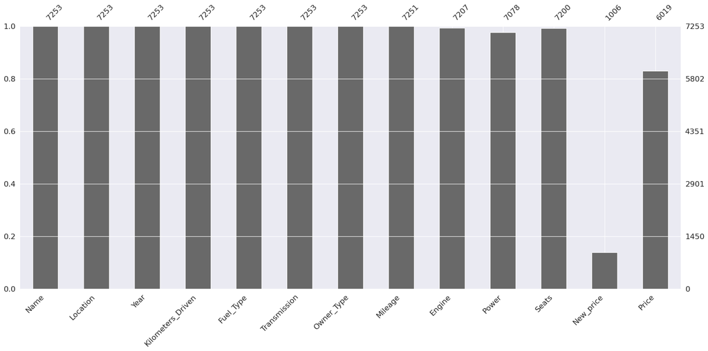

```python
#Visualize missing values
msno.bar(df)
```

```python
print("\nPercent of missing :\n\n", round(df.isna().sum() / df.isna().count() * 100, 2)) # looking at columns with most Missing Values
```

```
Percent of missing :

 Name                  0.00
Location              0.00
Year                  0.00
Kilometers_Driven     0.00
Fuel_Type             0.00
Transmission          0.00
Owner_Type            0.00
Mileage               0.03
Engine                0.63
Power                 2.41
Seats                 0.73
New_price            86.13
Price                17.01
dtype: float64
```

Observations:

- The dataset contains missing values in several variables: Mileage, Engine, Power, Seats, New_price, and Price.
- The New_price column has a large number of missing values—6247 in total, which makes up about 86% of the column. So we are going to drop the column.
- Price is also missing data, with 1234 entries—roughly 17% of the column.
- Seats information is missing for 53 entries. This detail is important as it has a big influence in the car's price.
- Year gives us the year when the car was manufactured, but that doesn't help us enough, so we will drop Year and create a new feature calle Age, where we will have the age in years of the car
- Engine has 46 missing values
- Mileage has only 2 missing values
- Power has 175 missing values

```python
# Specify the present year
current_year = 2024  # Update with the current year

# Create the 'Age' column
df['Age'] = current_year - df['Year']

df.drop(columns=['Year'], inplace=True)

#We drop New_price because it has too many missing values and will not be useful for the model
df.drop(columns=['New_price'], inplace=True)
```

```python
df.head()
```

|  | Name | Location | Kilometers_Driven | Fuel_Type | Transmission | Owner_Type | Mileage | Engine | Power | Seats | Price | Age |
| --- | --- | --- | --- | --- | --- | --- | --- | --- | --- | --- | --- | --- |
| 0 | Maruti Wagon R LXI CNG | Mumbai | 72000 | CNG | Manual | First | 26.60 | 998.0 | 58.16 | 5.0 | 1.75 | 14 |
| 1 | Hyundai Creta 1.6 CRDi SX Option | Pune | 41000 | Diesel | Manual | First | 19.67 | 1582.0 | 126.20 | 5.0 | 12.50 | 9 |
| 2 | Honda Jazz V | Chennai | 46000 | Petrol | Manual | First | 18.20 | 1199.0 | 88.70 | 5.0 | 4.50 | 13 |
| 3 | Maruti Ertiga VDI | Chennai | 87000 | Diesel | Manual | First | 20.77 | 1248.0 | 88.76 | 7.0 | 6.00 | 12 |
| 4 | Audi A4 New 2.0 TDI Multitronic | Coimbatore | 40670 | Diesel | Automatic | Second | 15.20 | 1968.0 | 140.80 | 5.0 | 17.74 | 11 |

## **Exploratory Data Analysis**

- EDA is an important part of any project involving data.
- It is important to investigate and understand the data better before building a model with it.
- A few questions have been mentioned below which will help you approach the analysis in the right manner and generate insights from the data.
- A thorough analysis of the data, in addition to the questions mentioned below, should be done.

**Questions:**

1. What is the summary statistics of the data? Explore summary statistics for numerical variables and the categorical variables
2. Find out number of unique observations in each category of categorical columns? Write your findings/observations/insights
3. Check the extreme values in different columns of the given data and write down the observtions? Remove the data where the values are un-realistic

```python
df.describe(include = "all").T
```

|  | count | unique | top | freq | mean | std | min | 25% | 50% | 75% | max |
| --- | --- | --- | --- | --- | --- | --- | --- | --- | --- | --- | --- |
| Name | 7253 | 2041 | Mahindra XUV500 W8 2WD | 55 | NaN | NaN | NaN | NaN | NaN | NaN | NaN |
| Location | 7253 | 11 | Mumbai | 949 | NaN | NaN | NaN | NaN | NaN | NaN | NaN |
| Kilometers_Driven | 7253.0 | NaN | NaN | NaN | 58699.063146 | 84427.720583 | 171.0 | 34000.0 | 53416.0 | 73000.0 | 6500000.0 |
| Fuel_Type | 7253 | 5 | Diesel | 3852 | NaN | NaN | NaN | NaN | NaN | NaN | NaN |
| Transmission | 7253 | 2 | Manual | 5204 | NaN | NaN | NaN | NaN | NaN | NaN | NaN |
| Owner_Type | 7253 | 4 | First | 5952 | NaN | NaN | NaN | NaN | NaN | NaN | NaN |
| Mileage | 7251.0 | NaN | NaN | NaN | 18.14158 | 4.562197 | 0.0 | 15.17 | 18.16 | 21.1 | 33.54 |
| Engine | 7207.0 | NaN | NaN | NaN | 1616.57347 | 595.285137 | 72.0 | 1198.0 | 1493.0 | 1968.0 | 5998.0 |
| Power | 7078.0 | NaN | NaN | NaN | 112.765214 | 53.493553 | 34.2 | 75.0 | 94.0 | 138.1 | 616.0 |
| Seats | 7200.0 | NaN | NaN | NaN | 5.280417 | 0.809277 | 2.0 | 5.0 | 5.0 | 5.0 | 10.0 |
| Price | 6019.0 | NaN | NaN | NaN | 9.479468 | 11.187917 | 0.44 | 3.5 | 5.64 | 9.95 | 160.0 |
| Age | 7253.0 | NaN | NaN | NaN | 10.634634 | 3.254421 | 5.0 | 8.0 | 10.0 | 13.0 | 28.0 |

Observations:

- There are 11 unique locations where the cars are being sold from
- The max value on Kilometers_Driven is 6500000, which doesn't seems to be realistc since the average is 58699.06
- The cars manufacturing year goes from 1996-2019
- There are 2041 unique names of cars
- The min value of Mileage is 0, we can transform those to null so we can treat them as missing values
- The min value of Engine doesn't look correct, since the average is 1616.57

**Let's check the count of each unique category in each of the categorical variables**

```python
# Making a list of all categorical variables
cat_col = list(df.select_dtypes("object").columns)

# Printing the count of each unique value
for column in cat_col:
    print(df[column].value_counts())
    print("-" * 50)
```

```
Name
Mahindra XUV500 W8 2WD                  55
Maruti Swift VDI                        49
Maruti Swift Dzire VDI                  42
Honda City 1.5 S MT                     39
Maruti Swift VDI BSIV                   37
                                        ..
Chevrolet Beat LT Option                 1
Skoda Rapid 1.6 MPI AT Elegance Plus     1
Ford EcoSport 1.5 TDCi Ambiente          1
Hyundai i10 Magna 1.1 iTech SE           1
Hyundai Elite i20 Magna Plus             1
Name: count, Length: 2041, dtype: int64
--------------------------------------------------
Location
Mumbai        949
Hyderabad     876
Coimbatore    772
Kochi         772
Pune          765
Delhi         660
Kolkata       654
Chennai       591
Jaipur        499
Bangalore     440
Ahmedabad     275
Name: count, dtype: int64
--------------------------------------------------
Fuel_Type
Diesel      3852
Petrol      3325
CNG           62
LPG           12
Electric       2
Name: count, dtype: int64
--------------------------------------------------
Transmission
Manual       5204
Automatic    2049
Name: count, dtype: int64
--------------------------------------------------
Owner_Type
First             5952
Second            1152
Third              137
Fourth & Above      12
Name: count, dtype: int64
--------------------------------------------------
```

Observations:

- Most cars Fuel_type are either diesel or petrol
- Most of the cars selling are from first or second owners
- Mahindra XUV500 W8 2WD, Maruti Swift VDI, Maruti Swift Dzire VDI are the top 3 most sold cars
- Manual transmission cars are sold more than twice as much compared to the automatic

## **Univariate Analysis**

**Questions:**

1. Do univariate analysis for numerical and categorical variables?
2. Check the distribution of the different variables? is the distributions skewed?
3. Do we need to do log_transformation, if so for what variables we need to do?
4. Perfoem the log_transformation(if needed) and write down your observations?

```python
# Function to plot a boxplot and a histogram along the same scale

def histogram_boxplot(data, feature, figsize = (12, 7), kde = False, bins = None):
    """
    Boxplot and histogram combined

    data: dataframe
    feature: dataframe column
    figsize: size of figure (default (12,7))
    kde: whether to show density curve (default False)
    bins: number of bins for histogram (default None)
    """
    f2, (ax_box2, ax_hist2) = plt.subplots(
        nrows = 2,      # Number of rows of the subplot grid = 2
        sharex = True,  # x-axis will be shared among all subplots
        gridspec_kw = {"height_ratios": (0.25, 0.75)},
        figsize = figsize,
    )                   # Creating the 2 subplots
    sns.boxplot(
        data = data, x = feature, ax = ax_box2, showmeans = True, color = "violet"
    )                   # Boxplot will be created and a star will indicate the mean value of the column
    sns.histplot(
        data = data, x = feature, kde = kde, ax = ax_hist2, bins = bins, palette = "winter"
    ) if bins else sns.histplot(
        data = data, x = feature, kde = kde, ax = ax_hist2
    )                   # For histogram
    ax_hist2.axvline(
        data[feature].mean(), color = "green", linestyle = "--"
    )                   # Add mean to the histogram
    ax_hist2.axvline(
        data[feature].median(), color = "black", linestyle = "-"
    )                   # Add median to the histogram
```

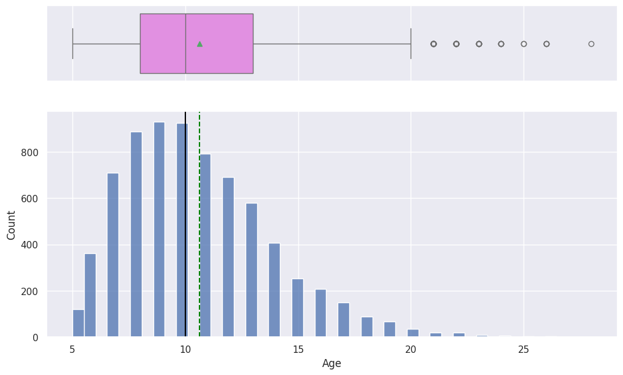

```python
histogram_boxplot(df, "Age")
```

Observations:

- Most of the cars are between 8-10 years old
- Some outliers above 20, those are the oldest cars

```
Skewness of 'Kilometers_Driven': 61.582574656174806
```

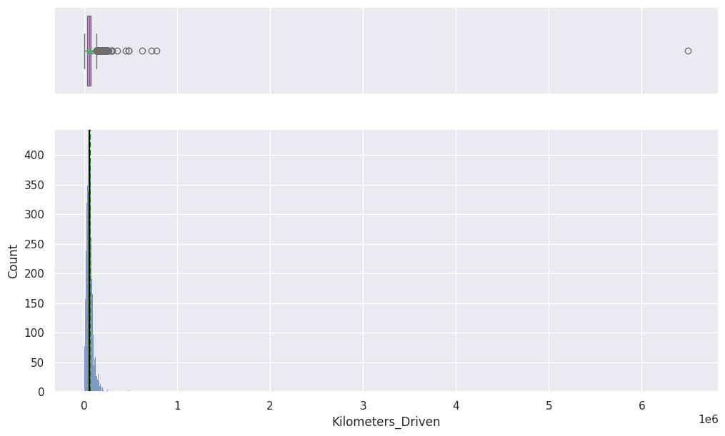

```python
histogram_boxplot(df, "Kilometers_Driven")
# Function to check the skewness of a variable
skewness_value = df['Kilometers_Driven'].skew()

print("Skewness of 'Kilometers_Driven':", skewness_value)
```

- Kilometers_Driven has an outlier value at 6500000, that is very unrealistic, we will remove that row from the dataset.
- Also the data is highly skewed so we will apply the log function.

```python
# Identify the row(s) with the outlier value(s)
outlier_rows_index = df[df['Kilometers_Driven'] == 6500000.0].index

# Drop the row(s) with outlier value(s)
df = df.drop(outlier_rows_index)

# Transform the feature 'Kilometers_Driven' with the log function and add it to the dataframe
df["kilometers_driven_log"] = np.log(df["Kilometers_Driven"])
```

```
Skewness of 'kilometers_driven_log': -1.3539415163105548
```

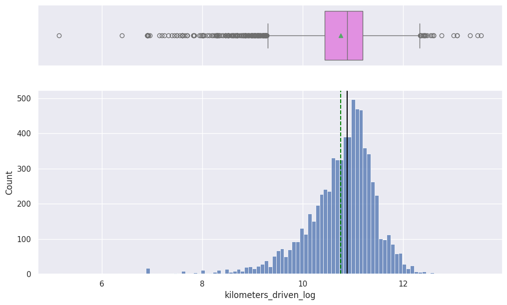

```python
histogram_boxplot(df, "kilometers_driven_log")
# Function to check the skewness of a variable
skewness_value = df['kilometers_driven_log'].skew()

print("Skewness of 'kilometers_driven_log':", skewness_value)
```

**Observations:**

- After getting rid of the outlier and applying the log function to the Kilometers_Driven feature we successfuly reduced the skewness of the distribution

```
Skewness of 'Mileage': -0.43849302953596925
```

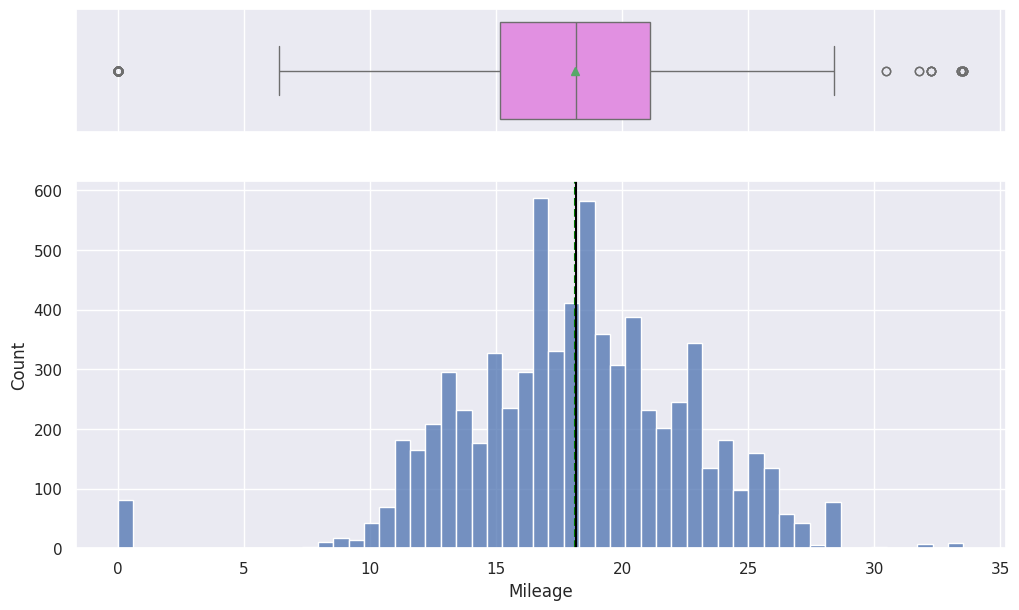

```python
histogram_boxplot(df, "Mileage")
# Function to check the skewness of a variable
skewness_value = df['Mileage'].skew()

print("Skewness of 'Mileage':", skewness_value)
```

There are several 0 values in the Mileage variable, this is not possible, so we will transform the 0 values to null and treat them later

**Transforming 0 values to null**

```python
# Replace 0.00 in 'Mileage' with NaN
df['Mileage'] = df['Mileage'].replace(0.00, np.nan)
df['Mileage'].isnull().sum()
```

```
83
```

```
Skewness of 'Mileage': 0.20494087213469345
```

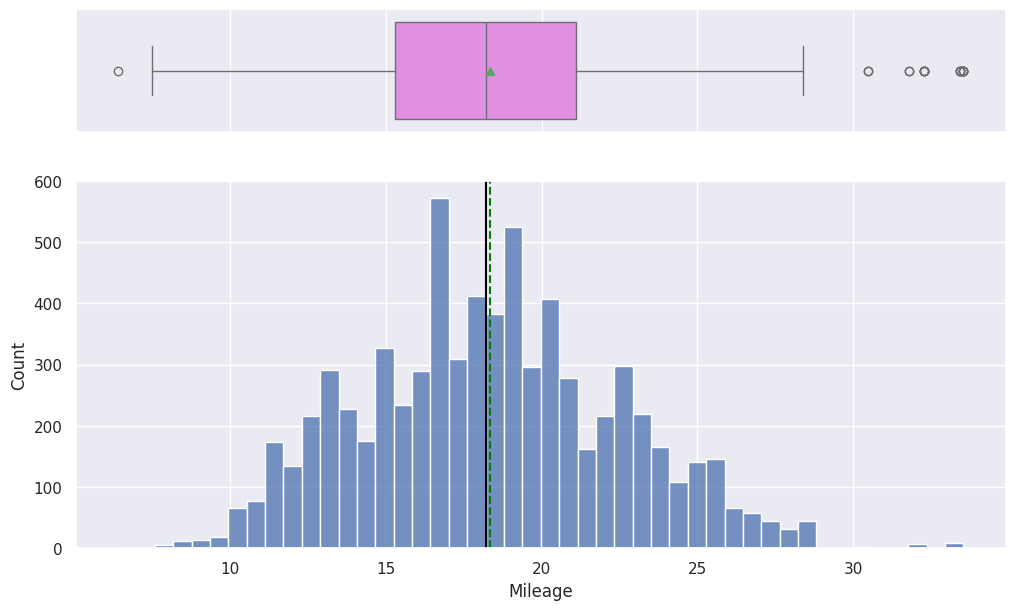

```python
histogram_boxplot(df, "Mileage")
# Function to check the skewness of a variable
skewness_value = df['Mileage'].skew()

print("Skewness of 'Mileage':", skewness_value)
```

**Observations:**

- Mileage has several 0 values, we will replace them to NaN, so we can treat them as a null value later on
- After transforming the 0 values to null we improved the skewness of the distribution and got rid of some outliers

```
Skewness of 'Engine': 1.413133430829896
```

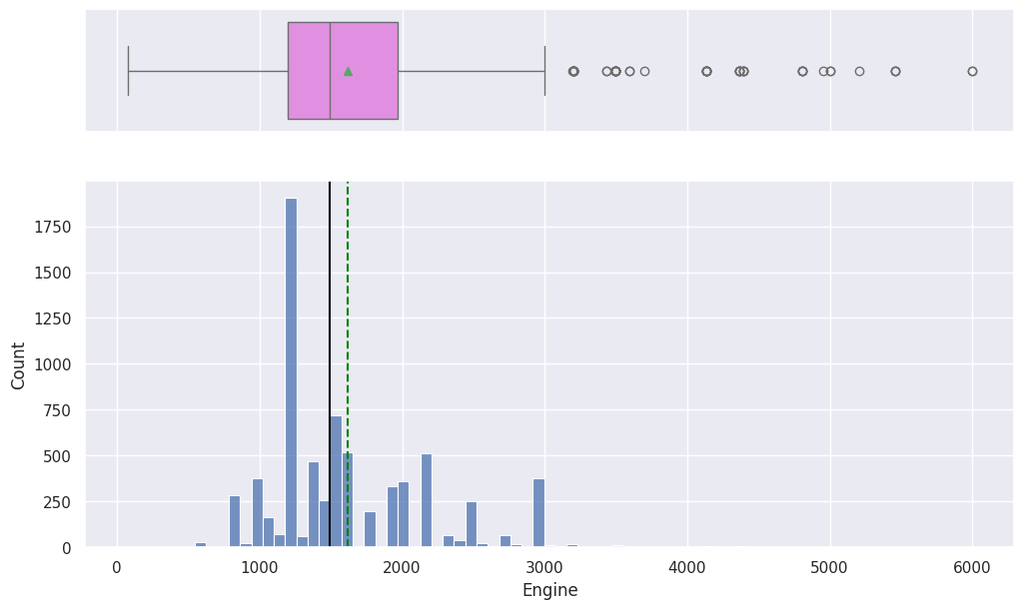

```python
histogram_boxplot(df, "Engine")
# Function to check the skewness of a variable
skewness_value = df['Engine'].skew()

print("Skewness of 'Engine':", skewness_value)
```

There seems to be a really low value on Engine, like we saw before the min value was 72, this will be an outlier and we should drop it

```python
df[df['Engine']< 624]
```

|  | Name | Location | Kilometers_Driven | Fuel_Type | Transmission | Owner_Type | Mileage | Engine | Power | Seats | Price | Age | kilometers_driven_log |
| --- | --- | --- | --- | --- | --- | --- | --- | --- | --- | --- | --- | --- | --- |
| 4446 | Mahindra E Verito D4 | Chennai | 50000 | Electric | Automatic | First | NaN | 72.0 | 41.0 | 5.0 | 13.0 | 8 | 10.819778 |

```python
# Identify the row(s) with the outlier value(s)
outlier_rows_index1 = df[df['Engine'] == 72.0].index

# Drop the row(s) with outlier value(s)
df = df.drop(outlier_rows_index1)
```

```
Skewness of 'Engine': 1.416367613080639
```

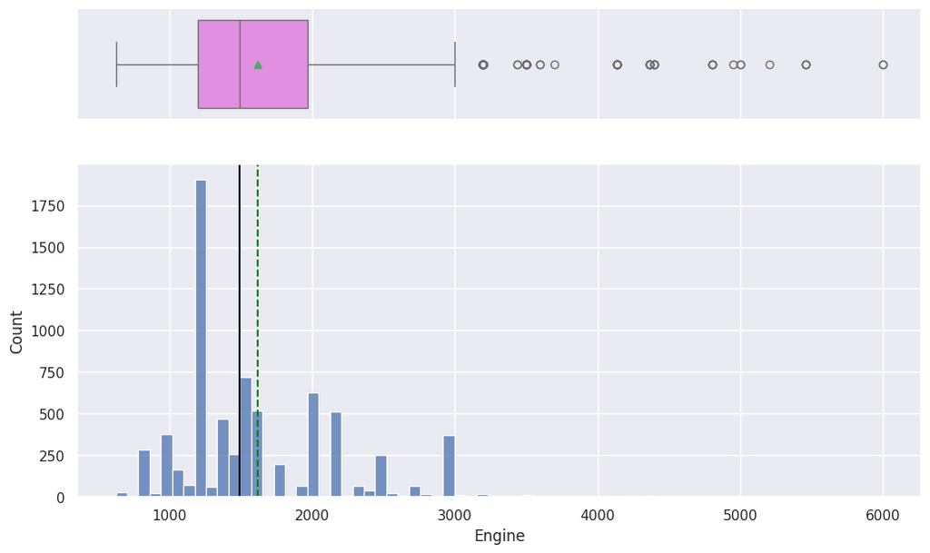

```python
histogram_boxplot(df, "Engine")
# Function to check the skewness of a variable
skewness_value = df['Engine'].skew()

print("Skewness of 'Engine':", skewness_value)
```

**Observations:**

- There are some outliers on Engine from 4000 to 6000, these are the fastest cars that have a bigger engine

```
Skewness of 'Power': 1.9628094842273558
```

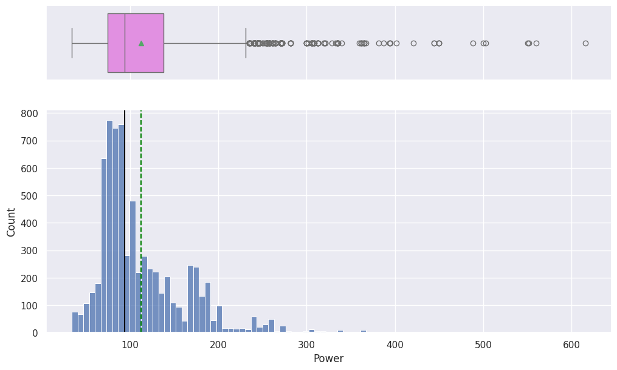

```python
histogram_boxplot(df, "Power")
# Function to check the skewness of a variable
skewness_value = df['Power'].skew()

print("Skewness of 'Power':", skewness_value)
```

**Observations:**

- Similar to engine, the power increases the speed of the car, there are outliers from 400 to 600, those are the most powerfull cars on the dataset

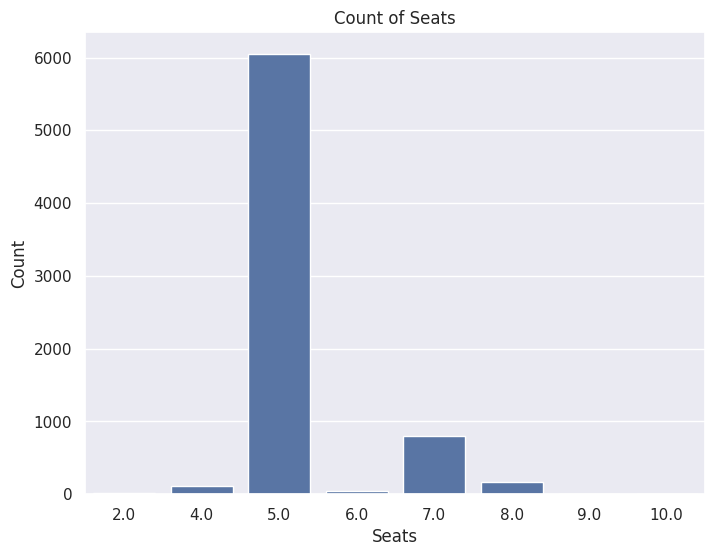

```python
# Create the count plot for the 'Seats' variable
plt.figure(figsize=(8, 6))
sns.countplot(x='Seats', data=df)
plt.title('Count of Seats')
plt.xlabel('Seats')
plt.ylabel('Count')
plt.show()
```

Observations:

- Most of the cars have 5 seats, that is the standard, follow by 7, 8 and 4

```
Skewness of 'Price': 3.3375344605464328
```

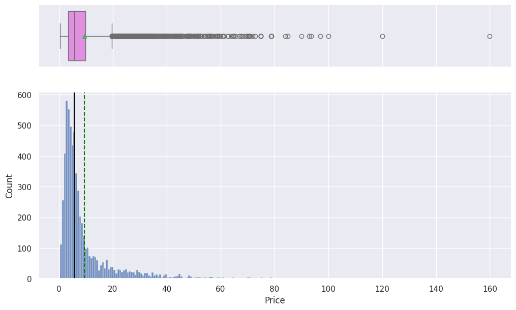

```python
histogram_boxplot(df, "Price")
# Function to check the skewness of a variable
skewness_value = df['Price'].skew()

print("Skewness of 'Price':", skewness_value)
```

Price variable is right skewed, we will use the log function to transform it and reduce skewness

```
Skewness of 'Price_log': 0.4165780596946553
```

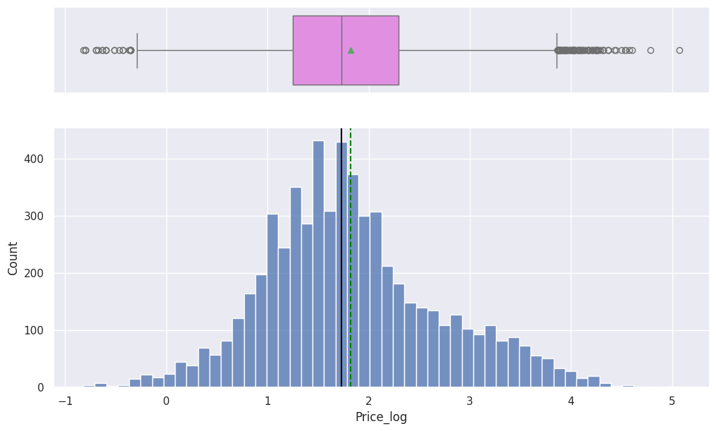

```python
# Transform the feature 'Price' with the log function and add it to the dataframe
df["Price_log"] = np.log(df["Price"])

# Function to check the skewness of a variable
skewness_value = df['Price_log'].skew()

print("Skewness of 'Price_log':", skewness_value)

histogram_boxplot(df, "Price_log")
```

Observations:

- After applying the log function to the variable Price we were able to considerably reduce the skewness of the distribution

```python
# Function to create labeled barplots

def labeled_barplot(data, feature, perc = False, n = None):
    """
    Barplot with percentage at the top

    data: dataframe
    feature: dataframe column
    perc: whether to display percentages instead of count (default is False)
    n: displays the top n category levels (default is None, i.e., display all levels)
    """

    total = len(data[feature])            # Length of the column
    count = data[feature].nunique()
    if n is None:
        plt.figure(figsize = (count + 1, 5))
    else:
        plt.figure(figsize = (n + 1, 5))

    plt.xticks(rotation = 90, fontsize = 15)
    ax = sns.countplot(
        data = data,
        x = feature,
        palette = "Paired",
        order = data[feature].value_counts().index[:n].sort_values(),
    )

    for p in ax.patches:
        if perc == True:
            label = "{:.1f}%".format(
                100 * p.get_height() / total
            )                              # Percentage of each class of the category
        else:
            label = p.get_height()         # Count of each level of the category

        x = p.get_x() + p.get_width() / 2  # Width of the plot
        y = p.get_height()                 # Height of the plot

        ax.annotate(
            label,
            (x, y),
            ha = "center",
            va = "center",
            size = 12,
            xytext = (0, 5),
            textcoords = "offset points",
        )                                 # Annotate the percentage

    plt.show()                            # Show the plot
```

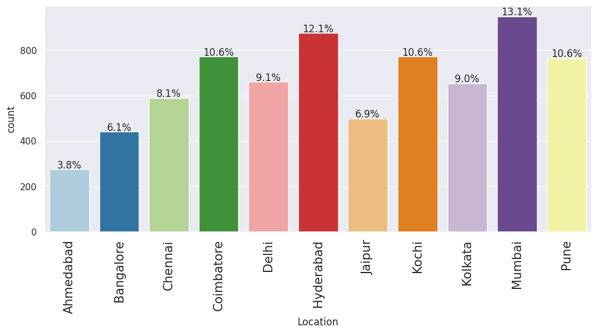

```python
labeled_barplot(df, "Location", perc = True)
```

**Observations:**

- Top 3 locations with more cars sold are Mumbai, Hyderabad and Kochi
- The location with the least cars sold is Ahmedabad with only 3.8%

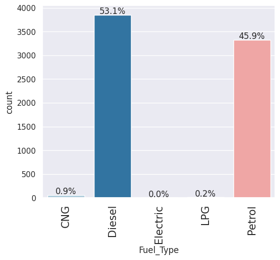

```python
labeled_barplot(df, "Fuel_Type", perc = True)
```

**Observations:**

- Most cars sold take Diesel or Petrol
- CNG, Electric and LPG take less than 1% of the cars each, this means that there are only a few cars with these Fuel types

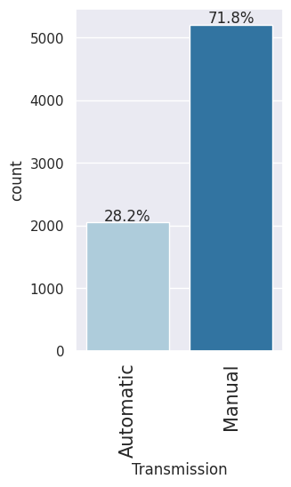

```python
labeled_barplot(df, "Transmission", perc = True)
```

**Observations:**

- The majority of cars are Manual, accounting for 71.8%, while the rest are Automatic, making up 28.2%.

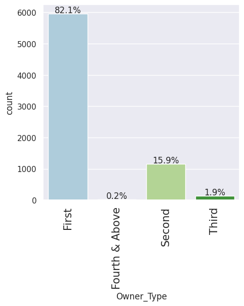

```python
labeled_barplot(df, "Owner_Type", perc = True)
```

**Observations:**

- The majority of cars are First Owner with a 82.1%, followed by Second with 15.9%, Third with 1.9% and Fourth and Above with only 0.2%
- There are only a few cars with Fourth and above Owner type, these cars have had several owners over time

## **Bivariate Analysis**

**Questions:**

1. Plot a scatter plot for the log transformed values(if log_transformation done in previous steps)?
2. What can we infer form the correlation heatmap? Is there correlation between the dependent and independent variables?
3. Plot a box plot for target variable and categorical variable 'Location' and write your observations?

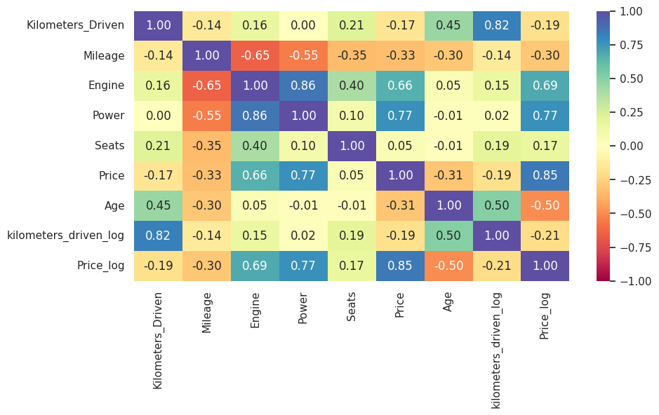

```python
cols_list = df.select_dtypes(include = np.number).columns.tolist()

plt.figure(figsize = (10, 5))
sns.heatmap(
    df[cols_list].corr(), annot = True, vmin = -1, vmax = 1, fmt = ".2f", cmap = "Spectral"
)
plt.show()
```

**Observations:**

- There is a big positive correlation between Power and Engine of 0.86
- There is a big positive correlations between Price_log and Power of 0.77
- There is a positive correlation between Price_log and Engine of 0.69
- There is a negative correlation between Price_log and Age of -50
- There is a negative correlation between Price_log and Mileage of -0.30
- There is a positive correlation between Age and kilometers_driven_log of 0.50
- There is a negative correlation between Engine and Mileage of -0.65
- There is a negative correlation between Power and Mileage of -0.55

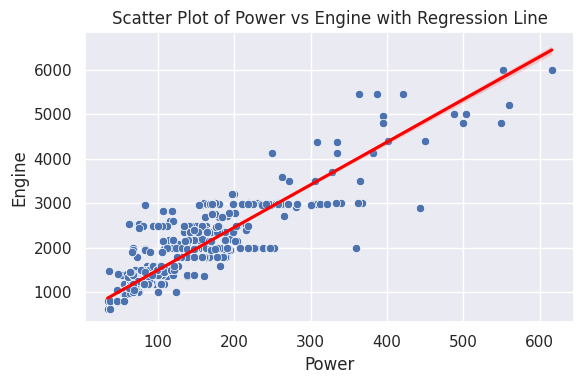

```python
plt.figure(figsize=(6, 4))

# Create scatter plot
sns.scatterplot(x='Power', y='Engine', data=df)

# Add regression line
sns.regplot(x='Power', y='Engine', data=df, scatter=False, color='red')

# Set plot title and axis labels
plt.title('Scatter Plot of Power vs Engine with Regression Line')
plt.xlabel('Power')
plt.ylabel('Engine')

# Adjust layout
plt.tight_layout()

# Show plot
plt.show()
```

**Observations:**

- Engine cc and power appear to be positively correlated, which is logical as larger or higher-quality engines typically yield greater power output.

[figure not shown]

```python
plt.figure(figsize=(6, 4))

# Create scatter plot
sns.scatterplot(x='Power', y='Price', data=df)

# Add regression line
sns.regplot(x='Power', y='Price', data=df, scatter=False, color='red')

# Set plot title and axis labels
plt.title('Scatter Plot of Power vs Price_log with Regression Line')
plt.xlabel('Power')
plt.ylabel('Price')

# Adjust layout
plt.tight_layout()

# Show plot
plt.show()
```

**Observations:**

- Price tends to rise in correlation with power; as the power of cars increases, so does their cost.

[figure not shown]

```python
plt.figure(figsize=(6, 4))

# Create scatter plot
sns.scatterplot(x='Engine', y='Price', data=df)

# Add regression line
sns.regplot(x='Engine', y='Price', data=df, scatter=False, color='red')

# Set plot title and axis labels
plt.title('Scatter Plot of Engine vs Price_log with Regression Line')
plt.xlabel('Engine')
plt.ylabel('Price')

# Adjust layout
plt.tight_layout()

# Show plot
plt.show()
```

**Observations:**

- Similarly to power, the price tends to rise with larger and faster engines.

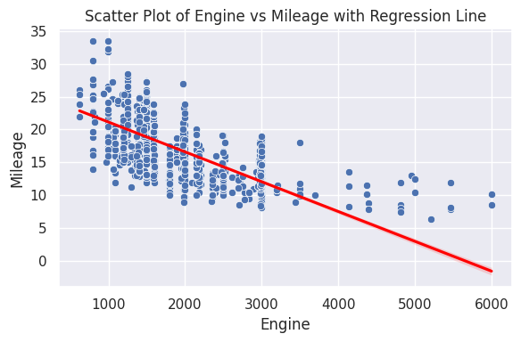

```python
plt.figure(figsize=(6, 4))

# Create scatter plot
sns.scatterplot(x='Engine', y='Mileage', data=df)

# Add regression line
sns.regplot(x='Engine', y='Mileage', data=df, scatter=False, color='red')

# Set plot title and axis labels
plt.title('Scatter Plot of Engine vs Mileage with Regression Line')
plt.xlabel('Engine')
plt.ylabel('Mileage')

# Adjust layout
plt.tight_layout()

# Show plot
plt.show()
```

**Observations:**

- The fuel efficiency appears to diminish in relation to the engine displacement; as engine CC increases, mileage tends to decrease accordingly

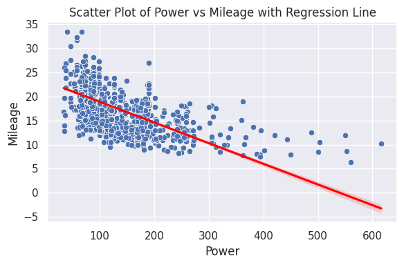

```python
plt.figure(figsize=(6, 4))

# Create scatter plot
sns.scatterplot(x='Power', y='Mileage', data=df)

# Add regression line
sns.regplot(x='Power', y='Mileage', data=df, scatter=False, color='red')

# Set plot title and axis labels
plt.title('Scatter Plot of Power vs Mileage with Regression Line')
plt.xlabel('Power')
plt.ylabel('Mileage')

# Adjust layout
plt.tight_layout()

# Show plot
plt.show()
```

**Observations:**

- The fuel efficiency appears to diminish in relation to power; as power increases, mileage tends to decrease accordingly.

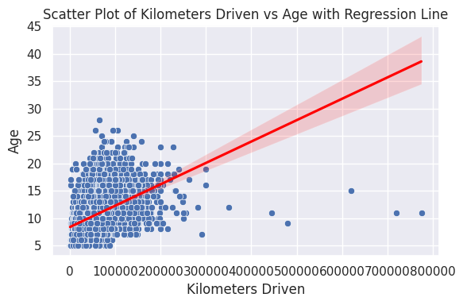

```python
plt.figure(figsize=(6, 4))

# Create scatter plot
sns.scatterplot(x='Kilometers_Driven', y='Age', data=df)

# Add regression line
sns.regplot(x='Kilometers_Driven', y='Age', data=df, scatter=False, color='red')

# Set plot title and axis labels
plt.title('Scatter Plot of Kilometers Driven vs Age with Regression Line')
plt.xlabel('Kilometers Driven')
plt.ylabel('Age')

# Adjust layout
plt.tight_layout()

# Show plot
plt.show()
```

**Observations:**

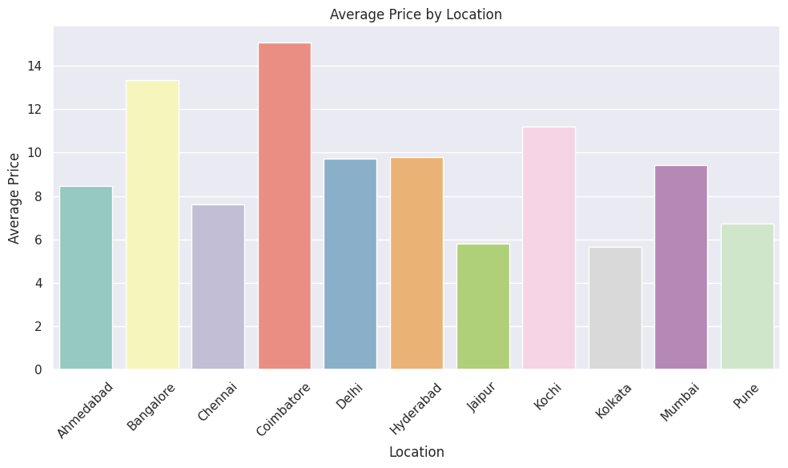

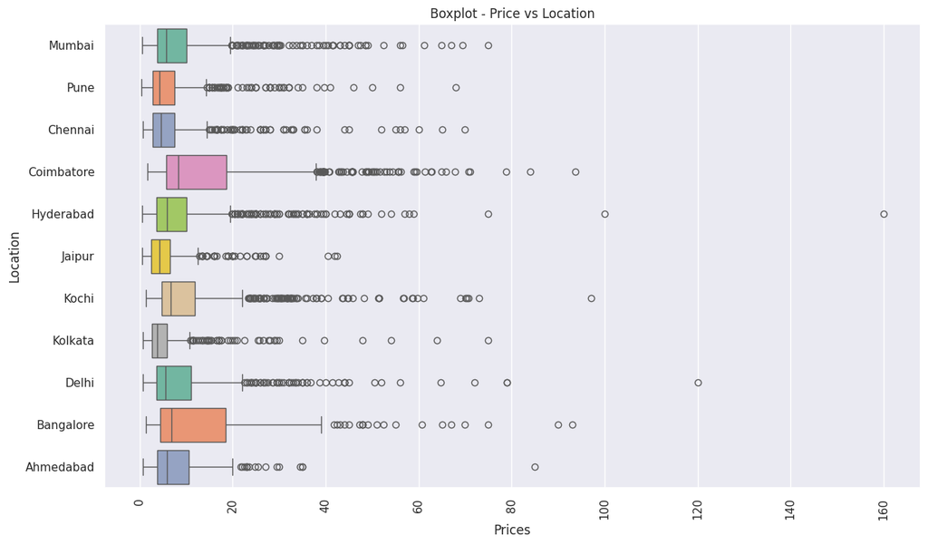

```python
# Group data by "Location" and calculate the average price
df_avg_price_location = df.groupby("Location")["Price"].mean().reset_index()

plt.figure(figsize=[10, 6])
plt.xticks(rotation=45)

# Create bar plot
bar_plot = sns.barplot(x='Location', y='Price', data=df_avg_price_location, palette='Set3')

# Set plot title and axis labels
plt.title('Average Price by Location')
plt.xlabel('Location')
plt.ylabel('Average Price')

# Show plot
plt.tight_layout()
plt.show()

# Set figure size
plt.figure(figsize=[14, 8])

# Create box plot
sns.boxplot(data=df, x='Price', y='Location', palette='Set2')

# Rotate x-axis labels for better readability
plt.xticks(rotation=90)

# Set plot title and axis labels
plt.title("Boxplot - Price vs Location")
plt.xlabel("Prices")
plt.ylabel("Location")

# Show plot
plt.show()
```

**Observations:**

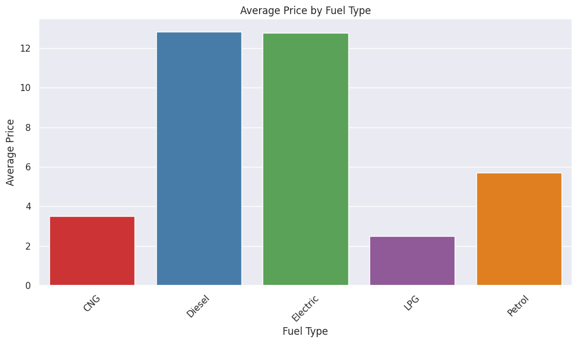

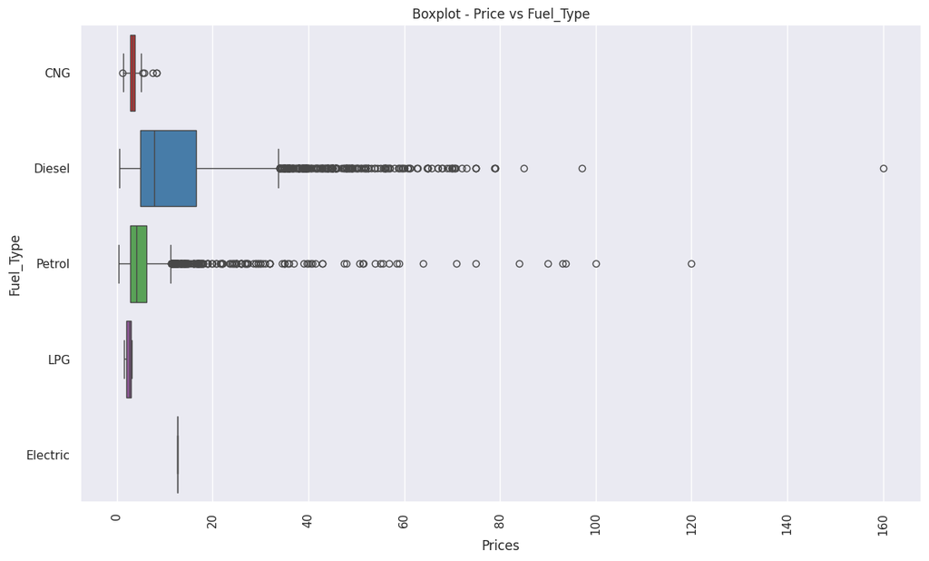

```python
# Group data by "Fuel_Type" and calculate the average price
df_avg_price_fuel = df.groupby("Fuel_Type")["Price"].mean().reset_index()

plt.figure(figsize=[10, 6])
plt.xticks(rotation=45)

# Create bar plot
bar_plot = sns.barplot(x='Fuel_Type', y='Price', data=df_avg_price_fuel, palette='Set1')

# Set plot title and axis labels
plt.title('Average Price by Fuel Type')
plt.xlabel('Fuel Type')
plt.ylabel('Average Price')

# Show plot
plt.tight_layout()
plt.show()

# Set figure size
plt.figure(figsize=[14, 8])

# Create box plot
sns.boxplot(data=df, x='Price', y='Fuel_Type', palette='Set1')

# Rotate x-axis labels for better readability
plt.xticks(rotation=90)

# Set plot title and axis labels
plt.title("Boxplot - Price vs Fuel_Type")
plt.xlabel("Prices")
plt.ylabel("Fuel_Type")

# Show plot
plt.show()
```

```python
# Filter the DataFrame for electric cars
df[df['Fuel_Type'] == 'Electric']
```

|  | Name | Location | Kilometers_Driven | Fuel_Type | Transmission | Owner_Type | Mileage | Engine | Power | Seats | Price | Age | kilometers_driven_log | Price_log |
| --- | --- | --- | --- | --- | --- | --- | --- | --- | --- | --- | --- | --- | --- | --- |
| 4904 | Toyota Prius 2009-2016 Z4 | Mumbai | 44000 | Electric | Automatic | First | NaN | 1798.0 | 73.0 | 5.0 | 12.75 | 13 | 10.691945 | 2.545531 |

There is only 1 car that runs on Electric Fuel_Type, we will remove it from the dataset

```python
# Drop rows where 'Fuel_Type' is equal to 'Electric'
df.drop(df[df['Fuel_Type'] == 'Electric'].index, inplace=True)
```

Now that we dropped the Electric Fuel type we can unify LPG and CNG for Gas since they both run on Gas Fuel

```python
# Replace 'CNG' and 'LPG' with 'Gas'
df['Fuel_Type'].replace({'CNG': 'Gas', 'LPG': 'Gas'}, inplace=True)
```

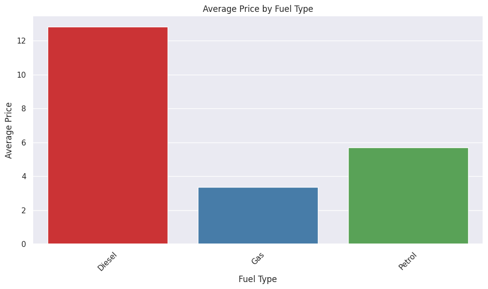

```python
# Group data by "Fuel_Type" and calculate the average price
df_avg_price_fuel = df.groupby("Fuel_Type")["Price"].mean().reset_index()

plt.figure(figsize=[10, 6])
plt.xticks(rotation=45)

# Create bar plot
bar_plot = sns.barplot(x='Fuel_Type', y='Price', data=df_avg_price_fuel, palette='Set1')

# Set plot title and axis labels
plt.title('Average Price by Fuel Type')
plt.xlabel('Fuel Type')
plt.ylabel('Average Price')

# Show plot
plt.tight_layout()
plt.show()
```

**Observations:**

- The average price of Electric cars is around 12 because there is only 1 electric car on the dataset, we removed it
- On average the most expensive cars run on Diesel, followed by Petrol
- The LPG and CNG cars are the least expensive, both under 4 in average price
- We transformed the Fuel_Type variable into only 3, Petrol, Diesel and Gas

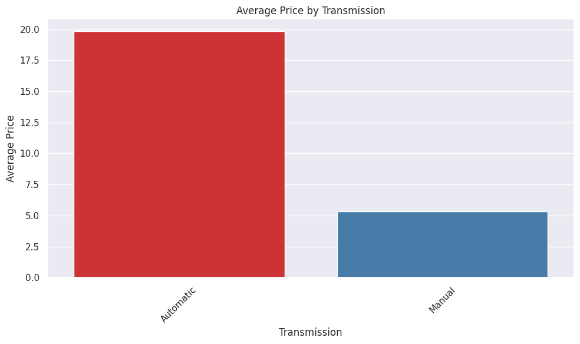

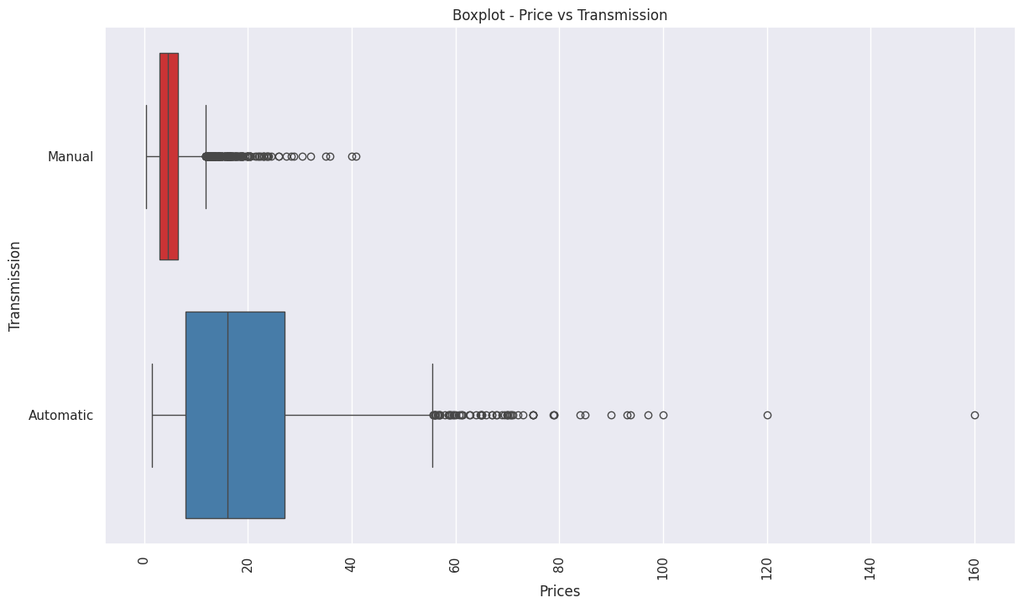

```python
# Group data by "Transmission" and calculate the average price
df_avg_price_transmission = df.groupby("Transmission")["Price"].mean().reset_index()

plt.figure(figsize=[10, 6])
plt.xticks(rotation=45)

# Create bar plot
bar_plot = sns.barplot(x='Transmission', y='Price', data=df_avg_price_transmission, palette='Set1')

# Set plot title and axis labels
plt.title('Average Price by Transmission')
plt.xlabel('Transmission')
plt.ylabel('Average Price')

# Show plot
plt.tight_layout()
plt.show()

# Set figure size
plt.figure(figsize=[14, 8])

# Create box plot
sns.boxplot(data=df, x='Price', y='Transmission', palette='Set1')

# Rotate x-axis labels for better readability
plt.xticks(rotation=90)

# Set plot title and axis labels
plt.title("Boxplot - Price vs Transmission")
plt.xlabel("Prices")
plt.ylabel("Transmission")

# Show plot
plt.show()
```

**Observations:**

- On average the Automatic cars are more expensive than Manuals

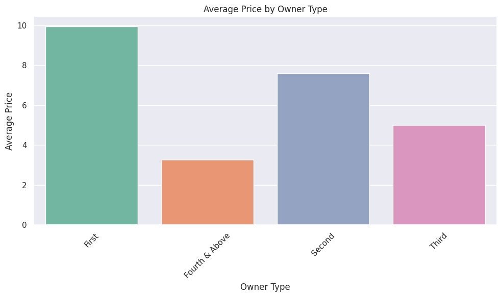

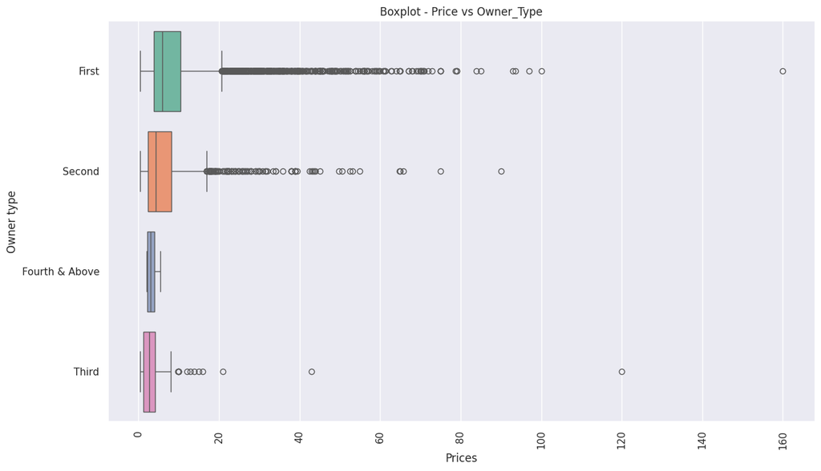

```python
# Group data by "Owner_Type" and calculate the average price
df_avg_price_owner = df.groupby("Owner_Type")["Price"].mean().reset_index()

plt.figure(figsize=[10, 6])
plt.xticks(rotation=45)

# Create bar plot
bar_plot = sns.barplot(x='Owner_Type', y='Price', data=df_avg_price_owner, palette='Set2')

# Set plot title and axis labels
plt.title('Average Price by Owner Type')
plt.xlabel('Owner Type')
plt.ylabel('Average Price')

# Show plot
plt.tight_layout()
plt.show()

# Set figure size
plt.figure(figsize=[14, 8])

# Create box plot
sns.boxplot(data=df, x='Price', y='Owner_Type', palette='Set2')

# Rotate x-axis labels for better readability
plt.xticks(rotation=90)

# Set plot title and axis labels
plt.title("Boxplot - Price vs Owner_Type")
plt.xlabel("Prices")
plt.ylabel("Owner type")

# Show plot
plt.show()
```

The owner type Fourth & above and Third both have few values, we are going to merge them and create one variable called Third & above

```python
# Replace 'Fourth & above' and 'Third' with 'Third & above'
df['Owner_Type'].replace({'Third': 'Third & Above', 'Fourth & Above': 'Third & Above'}, inplace=True)
```